# Apple Health Dashboard

[figure not shown]

[figure not shown]

### Leaflet is a JavaScript library for creating dynamic maps that support panning and zooming along with various annotations.

[interactive chart not shown]

https://github.com/irJERAD/AppleHealthDashboard

- Here you can see a Pin of my home in San Francisco!
- Interactive panning/zooming
- Compose maps using arbitrary combinations of map tiles, markers, polygons, lines, popups, and GeoJSON.
- Create maps right from the R console or RStudio
- Embed maps in knitr/R Markdown documents and Shiny apps
- Easily render Spatial objects from the sp package, or data frames with latitude/longitude columns
- Use map bounds and mouse events to drive Shiny logic

### ggplot2 - while well known and used - has a very diverse set of plot types; while old can be boring the selection is indispensable to data exploration and discovery.

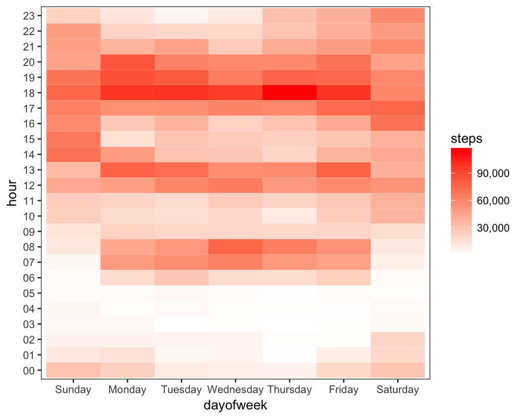

Here I used the (ggplot2)[https://github.com/hadley/ggplot2-book] libraries geometric tile plotting ability to create a heat map of my walking data

- Week Days around 6pm were the busiest time
  - This makes sense since that is when I am walking home from work
- This Library was written by one of my favorite data scientists

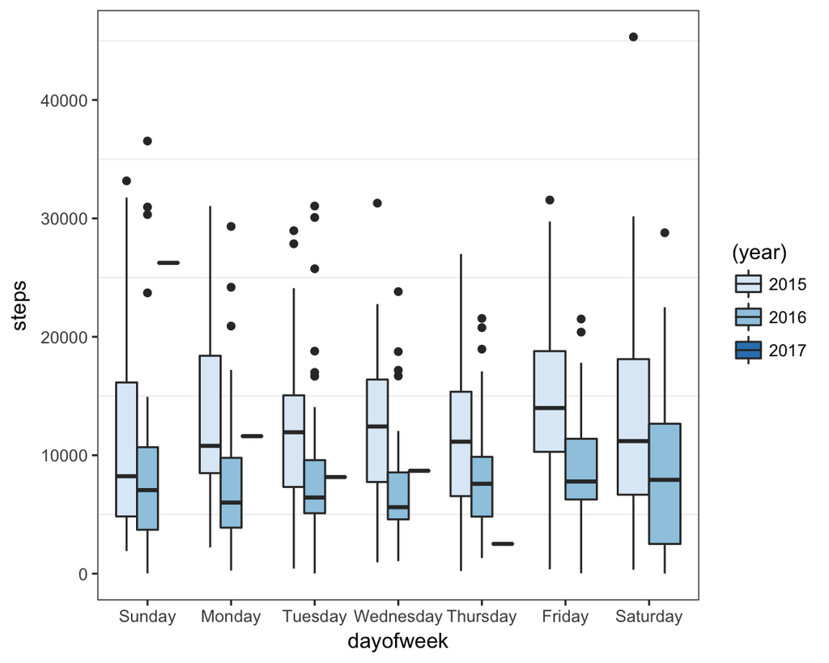

With 2017 only just starting (I am writing this at 10am on Jan 5th and only started last evening). A boxplot does really help much.

I considered filtering out this new year. However I am determined to impliment an automation that will continue to take my exported data and update this page - mostly because this is a static site and I love getting as much as possible from as little as necessary

````r
---
title: "Apple Health Dashboard"
output:
  flexdashboard::flex_dashboard:
    storyboard: true
    social: menu
    source: embed
---

```{r setup, include=FALSE}
library(flexdashboard)
library(dplyr)
library(ggplot2)
library(lubridate)
library(XML)

# Set path to export
exportPath <- "/Users/irJERAD/AppleHeathDashboard/apple_health_export/export.xml"

#load apple health export.xml file
xml <- xmlParse(exportPath)

#transform xml file to data frame - select the Record rows from the xml file
df <- XML:::xmlAttrsToDataFrame(xml["//Record"])

#make value variable numeric
## TODO fix error NAs introduced by coercion  (looks like a single extra row is added)
df$value <- as.numeric(as.character(df$value))

#make endDate in a date time variable POSIXct using lubridate with eastern time zone
df$endDate <-ymd_hms(df$endDate,tz="America/Los_Angeles")


##add in year month date dayofweek hour columns
df$month<-format(df$endDate,"%m")
df$year<-format(df$endDate,"%Y")
df$date<-format(df$endDate,"%Y-%m-%d")
df$dayofweek <-wday(df$endDate, label=TRUE, abbr=FALSE)
df$hour <-format(df$endDate,"%H")
```

### Leaflet is a JavaScript library for creating dynamic maps that support panning and zooming along with various annotations.

```{r}
library(leaflet)
leaflet() %>%
  addTiles() %>%
  addMarkers(lng=-122.4125580, lat=37.7781400, popup="Current Residence of Jerad")
```

***

https://github.com/irJERAD/AppleHealthDashboard

- Here you can see a Pin of my home in San Francisco!

- Interactive panning/zooming

- Compose maps using arbitrary combinations of map tiles, markers, polygons, lines, popups, and GeoJSON.

- Create maps right from the R console or RStudio

- Embed maps in knitr/R Markdown documents and Shiny apps

- Easily render Spatial objects from the sp package, or data frames with latitude/longitude columns

- Use map bounds and mouse events to drive Shiny logic


### ggplot2 - while well known and used - has a very diverse set of plot types; while old can be boring the selection is indispensable to data exploration and discovery.

```{r}
df %>%
  filter(type == 'HKQuantityTypeIdentifierStepCount') %>%
  group_by(date,dayofweek,hour) %>%
  summarize(steps=sum(value)) %>%
  group_by(hour,dayofweek) %>%
  summarize(steps=sum(steps)) %>%
  arrange(desc(steps)) %>%
  #print table steps by date by month by year
  ggplot(aes(x=dayofweek, y=hour, fill=steps)) +
  geom_tile() +
  scale_fill_continuous(labels = scales::comma, low = 'white', high = 'red') +
  theme_bw() +
  theme(panel.grid.major = element_blank())
```

***

Here I used the (ggplot2)[https://github.com/hadley/ggplot2-book] libraries geometric tile plotting ability to create a heat map of my walking data

- Week Days around 6pm were the busiest time
    - This makes sense since that is when I am walking home from work

- This Library was written by one of my favorite data scientists


### Dygraphs provides rich facilities for charting time-series data in R and includes support for many interactive features.

```{r}
df %>%
  filter(type == 'HKQuantityTypeIdentifierStepCount') %>%
  group_by(dayofweek,date,year) %>%
  summarize(steps=sum(value)) %>%
  #print table steps by date by month by year
  ggplot(aes(x=dayofweek, y=steps)) +
  geom_boxplot(aes(fill=(year))) +
  scale_fill_brewer() +
  theme_bw() +
  theme(panel.grid.major = element_blank())
```

***

With 2017 only just starting (I am writing this at 10am on Jan 5th and only started last evening). A boxplot does really help much.

I considered filtering out this new year. However I am determined to impliment an automation that will continue to take my exported data and update this page - mostly because this is a static site and I love getting as much as possible from as little as necessary

### Plotly provides bindings to the plotly.js library and allows you to easily translate your ggplot2 graphics into an interactive web-based version.
````